# Chapter4 Hypothesis tests(假設檢定) and sampling theory

2016年8月15日

## 4.1 Who should read this chapter?

This chapter is primarily aimed at readers who have never had any formal statistical training at all. We will aim to keep the formulas to a minimum and concentrate on the core ideas and practice.

## 4.2 Topics covered in this chapter

In this chapter we shall cover the absolute essentials of statistical hypothesis tests and confidence intervals(信賴區間) and some of the theory behind them. we will need to be able to understand hypothesis tests and confidence intervals so that we can decide whether the results we see from a statistical method are meaningful or significant. We will also cover the parts of R that let you do things like carry out a two sample t-test, calculate a confidence interval, and find a P-value.

## 4.4 Statistical distributions

We need this section is that many of the tests and techniques rely on certain assumptions. The assumptions often are that the data, or a statistic calculated from the data, follow a specific statistical distribution. Sometimes these are reasonable assumptions to make.

## 4.4.1 Some concepts and notation(標記)

A random experiment is an experiment where we cannot predict the outcome in advance(可能的結果). We might know the range of possible outcomes, but we do not know the specific outcome until we carry out the experiment.

Some forensic examples of random experiments might be:

‧ Counting the number of fibers found on a car seat;  
‧ Measuring the length of a footprint;  
‧ Determining the RI of a piece of glass;  
‧ Measuring the spectra(光譜) of a paint sample.

## 4.4.1-2 Some concepts and notation

A random variable is a variable that measures the outcome of a random  
experiment. Some examples of random variables, using the random experiments  
in the previous paragraph, are  
‧ The number of fibers;  
(纖維數量,構造的數量) ‧ The length in millimeters (mm);  
‧ The RI;  
‧ The positions or wavelengths(波長) at which peaks occurred.

It is statistical convention to denote a random variable with an uppercase italic letter, and the outcome of a specific random experiment with a lowercase italic letter,X is a random variable and an outcome from a particular measurement, x.

## 4.4.1-3 Some concepts and notation

A probability of 0 means that the event will never occur and a probability of 1 means that the event will always occur. Probabilities are also sometimes expressed in the form of odds.

if I tell you that the probability of a certain event occurring is P = 0.25 (25%), then the odds are

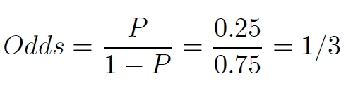

Odds are usually expressed as a ratio so our probability of 0.25 becomes odds of 1:3 or “one to three against.”

## 4.4.2 The normal distribution

The normal distribution(常態分布) is a mathematical formalization of the idea that “observations tend to cluster around the mean.”However, there is a situation where this observation becomes stronger and that is in the behavior of the sample mean. The behavior of the sample mean is described by the Central Limit Theorem.(中央極限定理)

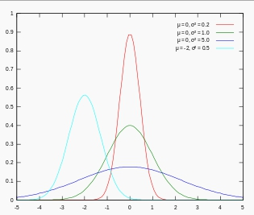

## 4.4.2-2 The normal distribution

we say data are normally distributed if a histogram or a kernel density estimate of the data is

‧ unimodal;  
單峰 ‧ symmetric;  
對稱 ‧ and the observations tend to cluster around the mean.  
緊密分部在空間中

The normal distribution is characterized by the mean μ and the standard deviation . The mean specifies where the distribution is centered and the standard deviation specifies the spread of the distribution.

## 4.4.2-3 The normal distribution

Figure 4.1 shows normal distributions with different means. In this plot μ1 < μ2 < μ3. Figure 4.2 shows normal distributions with different standard deviations. In this plot o1 < o2 < o3. When μ = 0 and o = 1, the normal distribution is referred to as the standard normal.

## 4.4.2-4 The normal distribution

Figure 4-1

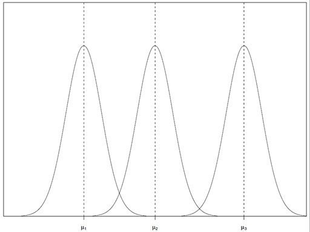

## 4.4.2-5 The normal distribution

Figure 4-2

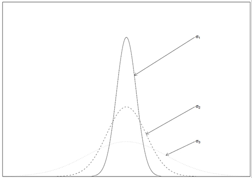

## 4.4.2-6 The normal distribution

we call the resulting numbers the z-scores. The z-scores tell us how many standard deviations each observation is away from the mean.

## 4.4.3 Student’s t-distribution

Student’s t-distribution [20] is closely related to the normal distribution.The principal difference is that t-distribution has “fatter” tails(左右兩側比較高) that allow more variability in the data than the normal distributions.

It is primarily used in situations where we have a small amount of data and therefore increased uncertainty in our estimates of the mean and the standard deviation.

Figure 4.3 shows the effect of the degrees of freedom. As the degrees of freedom decrease, the “peak” of the curve gets lower, and the tails get fatter.

## 4.4.3-2 Student’s t-distribution

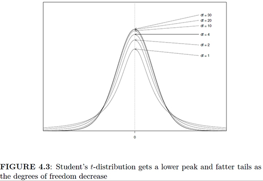

## 4.4.4 The binomial distribution(二項分佈)

The binomial distribution is used when we have data that record “the number of successes in a fixed number of experiments.”

Some examples where binomial data might arise are  
‧ A sample of 100 unrelated people is genotyped (基因型)and the number of A alleles(對偶基因) at the Gc(group-specific component 群組特定成分) locus(位置) are counted for each person;  
‧ A particular DNA profile (基因特性或資料)is genotyped 10 times and the number of “dropout” events are counted;  
‧ A random sample of 50 adult males is taken and the number of men wearing size 12 shoes or larger is recorded.

## 4.4.4-2 The binomial distribution(二項分佈)

There are four key assumptions that must be met in order for the binomial distribution to be used. These are  
1. In each trial there must only be two possible outcomes: “success(成功)” and “failure(失敗)”;  
2. Each trial(實驗,測試) must be independent(獨立的) of all previous trials;  
3. Each trial must have a constan(常態的,不變的)t probability of success;  
4. The number of trials must be fixed(固定不變的) in advance(數量必須預先決定).

## 4.4.4-3 The binomial distribution(二項分佈)

Let us take our third example to see how we might apply these assumptions. A trial in this example is seeing whether a particular male has size 12 shoes or bigger. success = “size 12 or bigger,” and failure = “smaller than size 12.” Each trial is independent of the previous trial because we have no real reason to think that the shoe size of one man should be related to the shoe size of another man.

The behavior binomial distribution is controlled by two parameters, n, the number of trials, and p, the probability of success.

The binomial distribution a key component of the logistic regression model. The core idea is that if we have binomial data where we believe the probability of success is affected by another variable, then we can use logistic regression to model this data.

## 4.4.5 The Poisson distribution(帕松分佈)

The Poisson distribution is very useful for dealing with count data where there is no fixed number of trials.

The Poisson distribution has a single parameter, its mean 入.

## 4.4.6 The X2-distribution

The X2 (or chi-squared) distribution is encountered mainly in two situations that are actually related. Tests of goodness-of-fit and tests of independence both use the X2-distribution. The 2-distribution is characterized by a degrees of freedom parameter. the degrees of freedom parameter is related to the sample size.

## 4.4.7 The F-distribution

The F-distribution in the interpretation of linear models. It is useful when the statistic of interest is a ratio of variances(變異數的比率).

## 4.4.8 Distribution terminology(分佈的術語)

If the distribution is discrete, like the binomial or Poisson, for example, then this curve(曲線) is called a probability function and can be represented as a histogram. If the distribution is continuous, like the normal or t, then the curve is called a probability density function or pdf(機率密度函式).

The probability of a particular value for a discrete distribution or for a range of values for a continuous distribution is given by another curve called the cumulative distribution function (累積分佈函式)or cdf.

## 4.5 Introduction to statistical hypothesis testing

Statistical hypothesis testing is a formal, objective, repeatable way of making inferential(推理) statements based on data.  
That is, it is a scientific method for assessing the importance or relevance(適當的) of experimental findings based on one or more sets of data.

## 4.5.1 Statistical inference(統計推論)

Statistical inference is the process of using a “sample” of data to say something about a “population.”(用部分樣本去討論整體)

## 4.5.1.1 Notation

A convention in statistics is to represent parameters or population values with Greek letters and a sample estimate as a letter from the alphabet or Greek letter with a “hat.”

## 4.5.2 A general framework for hypothesis tests

The steps involved in a hypothesis test are generally the same regardless of the type of test being carried out.

1. Ask a question;
2. Formulate your question statistically—that is, find a statistic you think(用統計的方式去整理陳述你的問題) might answer your question;
3. Propose a null hypothesis;
4. Propose an alternative hypothesis;
5. Calculate your test statistic;
6. Calculate the P-value;
7. Interpret the P-value.

## 4.5.2-2 A general framework for hypothesis tests

The null hypothesis(虛無假設) might be called “the hypothesis of no interest.” In general, the null hypothesis is one of no effect or no difference. For example, if we are interested in the difference between the two population probabilities, then the null hypothesis is that there is no difference. If we are interested in the difference between group means, then the null hypothesis will be that there is no difference between the groups. ##4.5.2-3 A general framework for hypothesis tests

The appropriate test statistic depends on the situation. The keys to choosing an appropriate test statistic are  
‧ It is a good summary of what you are interested in; ‧ It has different behavior under each of the hypotheses. That is, it behaves  
differently if the alternative hypothesis is true rather than the null hypothesis;  
‧ The distribution of the statistic when the null hypothesis is true is known.

## 4.5.2-4 A general framework for hypothesis tests

if the statistic conforms to a well-known statistical distribution, then we can use our knowledge of that distribution to calculate the P-value easily.  
The P-value is the probability of observing a test statistic as large as or larger than the one you have observed if the null hypothesis is true.

P-values do not tell us the probability that the null hypothesis is true. Pvalues do not tell us the probability that the alternative hypothesis is true. P-values tell us the probability of observing our test statistic by random chance alone (i.e., if the null hypothesis is true).

## 4.5.2-5 A general framework for hypothesis tests

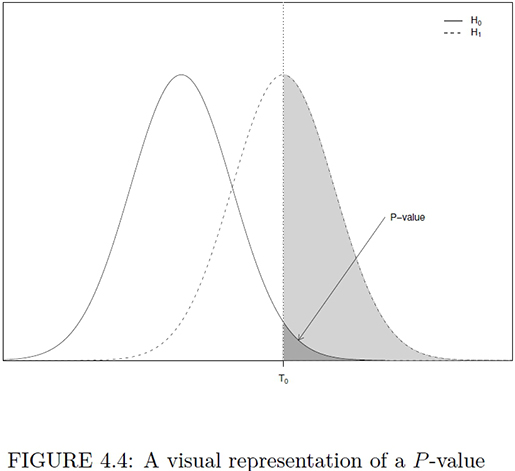

## 4.5.2-6 A general framework for hypothesis tests

If the P-value is  
‧ greater than 0.1, then we say, “there is no evidence against H0”  
‧ between 0.05 and 0.1, then we say, “there is weak evidence against H0  
‧ between 0.01 and 0.05, then we say, “there is evidence against H0”  
‧ between 0.001 and 0.01, then we say, “there is strong evidence against H0”  
‧ less than 0.001, then we say, “there is very strong evidence against H0”

## 4.5.3 Confidence intervals(信賴區間)

We use confidence intervals to quantify the uncertainty in our estimates. Confidence intervals are expressed as a range with an associated confidence level.

## 4.5.3.1 The relationship between hypothesis tests and confidence

There is a relationship between two-tailed hypothesis tests and confidence intervals. A two-tailed hypothesis test is one where there is no direction in the alternative hypothesis(對立假設).

## 4.5.3.1-2 The relationship between hypothesis tests and confidence

Our P-value is calculated by adding the lower and upper tail probability together. That is, if our test statistic, T, has value T0 and we assume T0 > 0, then the P-value is  
P = Pr(T >= T0) + Pr(T >= T0)

## 4.5.4 Statistically significant, significance level(顯著性水平), significantly different(顯著性差益), confidence, and other confusing phrases

We are 95% confident that there is a significant difference.” The first source of confusion is that people often express significance levels as either proportions or percentages.

## 4.5.5 The two sample t-test

The two sample t-test is used when we have two independent groups of subjects or objects for which we have measured a single quantitative variable.

## 4.5.6 The sampling distribution of the sample mean and other statistics

The possible outcomes for each experiment are 1, 2, 3, or 4. Each outcome is equally likely.

Pr(Xi = x) = 0.25, i = 1, 2 and x = 1, 2, 3, 4. This probability function is represented graphically in Figure 4.7.

“What is the probability function for the sum?” That is, if S = X1 + X2, then what is Pr(S = s)? Firstly, let us think about the possible outcomes. The smallest value that X1 and X2 can have is 1; therefore, the smallest sum is 2. Similarly, the largest value each experiment can have is 4, so the largest sum is 8. It should not be too hard to see that every other value between 2 and 8 is possible for the sum,

## 4.5.6-2 The sampling distribution of the sample mean and other statistics

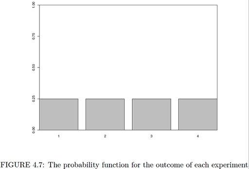

## 4.5.6-3 The sampling distribution of the sample mean and other statistics

The next question is, “Is every value of the sum S equally likely?”

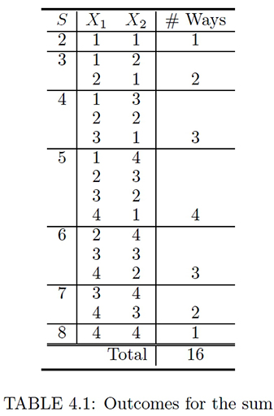

## 4.5.6-4 The sampling distribution of the sample mean and other statistics

The probability of each value of the sum.

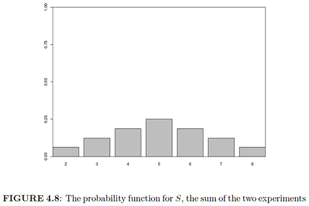

## 4.5.6-5 The sampling distribution of the sample mean and other statistics

The Central Limit Theorem (CLT) If X1,X2, …,Xn are independent random variables with the same distribution, then the sum of these variables S = X1 + X2 + · · · + Xn (and hence also the mean) will have an approximately normal distribution.

## 4.5.6-6 The sampling distribution of the sample mean and other statistics

Corollary to the CLT  
If the standard deviation of the population (or distribution) is a, then the standard deviation of the sample mean is a/跟號n.  
We estimate the standard deviation of the sample mean by s/跟號x . This estimated standard deviation is known as the standard error.

if the data come from a symmetric unimodal distribution, or something near to that, then the CLT ensures that the distribution of the sample mean will be very close to normal for samples of size 30.

## 4.5.7 The x2-test of independence

The x2 (chi-squared) test of independence is used to analyze tables of counts for two or more variables. That is, situations where we have two or more categorical variables for which we have counted the number of observations falling into the categories formed by the “crossing” of these variables.

The degrees of freedom in the x2-test relate to the number of rows and columns in the frequency table. It provides a useful check that the computer has treated the data correctly. If there are I row categories and J column categories, then the degrees of freedom should be (I ??? 1) × (J ??? 1).

## Comparing two proportions

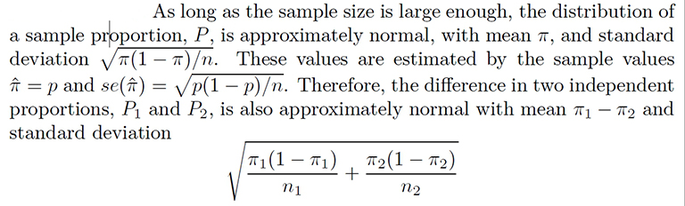

## 4.5.7.5 Fisher’s exact test(費雪爾正確性檢定)

The x2-test is a large sample approximation. This means that in order for the test to give sensible results we need a relatively large sample size. (檢定兩個類別型變數間是否存在關聯性)

## 4.5.7.7 Example 4.7—Age and gender of victims of crime

Aitken et al. [28] were interested in whether there was a relationship between the gender and age of the victims in certain crimes.The age of the victims had been classified as 0–10 and 11+.

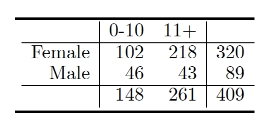

## 4.5.7.7-2 Example 4.7—Age and gender of victims of crime

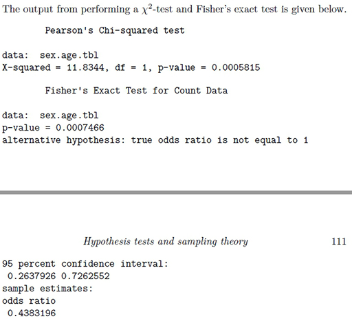

## 4.6 Tutorial

Load the Bennett et al. data set.  
Recall this data consist of 49 groups of RI observations, with 10 observations per group. Therefore, to perform a two sample t-test on groups 1 and 3 we can type

## 4.6 Tutorial-2

```
##
##  Welch Two Sample t-test
##
## data:  bennett.df$X1 and bennett.df$X3
## t = 0.25072, df = 17.947, p-value = 0.8049
## alternative hypothesis: true difference in means is not equal to 0
## 95 percent confidence interval:
##  -1.18104e-05  1.50104e-05
## sample estimates:
## mean of x mean of y
##  1.520010  1.520008
```

## 4.6 Tutorial-3

There are only 10 observations per group, so a box plot is not appropriate. A simple scatter plot of the observations by group should suffice. we need to make a grouping variable using the rep command and we need to put the RI information for both groups into a single vector.

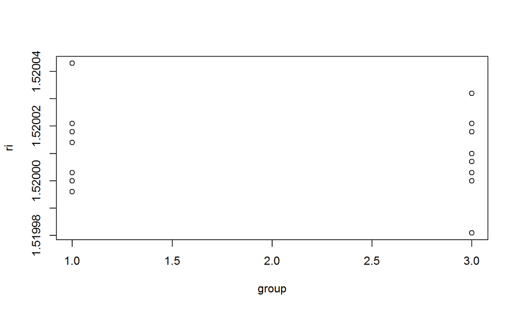

##4.6 Tutorial-4

算出T分佈的資料

```
##
##  Welch Two Sample t-test
##
## data:  bennett.df$X1 and bennett.df$X3
## t = 0.25072, df = 17.947, p-value = 0.8049
## alternative hypothesis: true difference in means is not equal to 0
## 95 percent confidence interval:
##  -1.18104e-05  1.50104e-05
## sample estimates:
## mean of x mean of y
##  1.520010  1.520008
```

```
##
##  Welch Two Sample t-test
##
## data:  ri by group
## t = 0.25072, df = 17.947, p-value = 0.8049
## alternative hypothesis: true difference in means is not equal to 0
## 95 percent confidence interval:
##  -1.18104e-05  1.50104e-05
## sample estimates:
## mean in group 1 mean in group 3
##        1.520010        1.520008
```

## 4.6 Tutorial-5

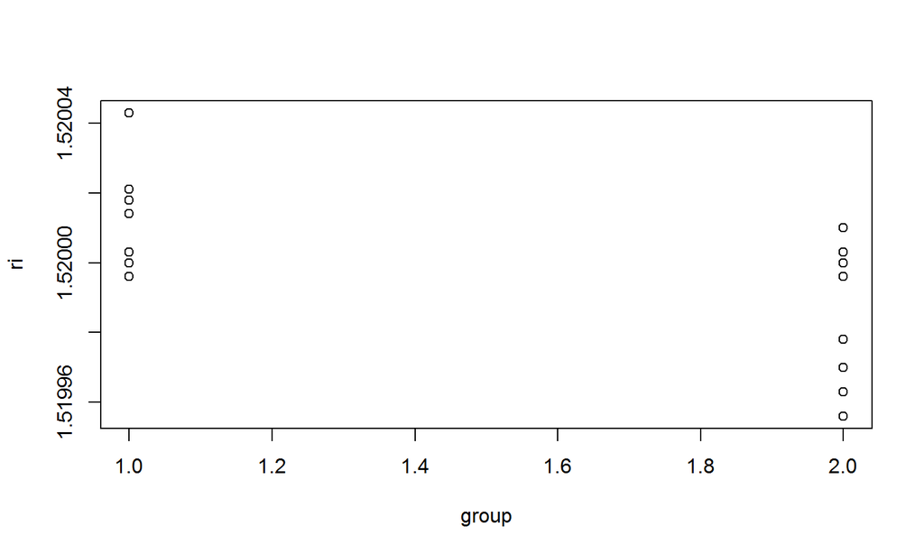

```
##
##  Welch Two Sample t-test
##
## data:  ri by group
## t = 2.6622, df = 16.484, p-value = 0.01673
## alternative hypothesis: true difference in means is not equal to 0
## 95 percent confidence interval:
##  4.297092e-06 3.750291e-05
## sample estimates:
## mean in group 1 mean in group 2
##        1.520010        1.519989
```

## 4.6 Tutorial-6

whether there was a relationship between whether the victim had been abducted and the age of the victims in certain crimes.(被誘拐的受害者是否與其年齡有關)  
The age of the victims had been classified as 0–10 and 11+. This data is stored in the dafs library as abduct.age.df. Load the data and cross tabulate it by abduct and age.

```
## [1] "abduct" "age"
```

```
##       age
## abduct 0-10 11+
##    No    92 198
##    Yes   37  26
```

## 4.6 Tutorial-7

Perform a x2-test of independence to see whether there is an association between abduct and age.

```
##
##  Pearson's Chi-squared test
##
## data:  abduct.tbl
## X-squared = 16.278, df = 1, p-value = 5.47e-05
```

## 4.6 Tutorial-8

We can examine the expected values used in the x2-test by storing the test result and extracting the expected values using $expected.

```
## [1] "statistic" "parameter" "p.value"   "method"    "data.name" "observed"
## [7] "expected"  "residuals" "stdres"
```

```
##       age
## abduct      0-10       11+
##    No  105.97734 184.02266
##    Yes  23.02266  39.97734
```

## 4.6 Tutorial-9

Compare the results of the 2-test with Fisher’s exact test.

```
##
##  Fisher's Exact Test for Count Data
##
## data:  abduct.tbl
## p-value = 8.458e-05
## alternative hypothesis: true odds ratio is not equal to 1
## 95 percent confidence interval:
##  0.1788801 0.5925419
## sample estimates:
## odds ratio
##  0.3276427
```

## 4.6 Tutorial-10

We can use a x2-test or Fisher’s exact test to see whether there are differences in the genotype proportions of the different racial groups.

```
##         genotype
## racecode  AA  AB  AC  BB  BC  CC
##        A   1  28   6 117  46   7
##        C  19  24  60   4  29  63
##        H   9  20  48  15  62  54
```

```
##
##  Pearson's Chi-squared test
##
## data:  gc.tbl
## X-squared = 287.66, df = 10, p-value < 2.2e-16
```

## 4.6 Tutorial-11

The Monte Carlo version of Fisher’s exact test requires us to tell R how many “samples” to take. In general, all Monte Carlo procedures become more accurate the bigger the sample size. For most Fisher’s exact test, a sample size of 100,000 should be quick and sufficient:

```
##
##  Fisher's Exact Test for Count Data with simulated p-value (based
##  on 1e+05 replicates)
##
## data:  gc.tbl
## p-value = 1e-05
## alternative hypothesis: two.sided
```